# 3.5 - Noah's Notes - Logistic regression from scratch

Four months after the supply-prediction project, Minermont Hospital faces a new question: **will a patient attend their appointment?** Across the hospital about 18% of appointments are missed, and in some specialties up to 27%. Physiotherapy has the highest rate, so the pilot starts there.

This time we do not predict a quantity, like the masks of chapter 2, but a yes/no answer: a **binary classification** problem. Logistic regression keeps the linear score of linear regression, $z = w \cdot x + b$, and passes it through the **sigmoid** function, which turns any number into a probability between 0 and 1:

$$\hat{p} = \sigma(z) = \frac{1}{1 + e^{-z}}$$

If $\hat{p}$ is above a **threshold** (usually 0.5), we predict that the patient will not attend.

In this notebook we build it from scratch with NumPy, just as we did with linear regression:

1. Import the libraries.
2. Create a synthetic dataset of Physiotherapy appointments.
3. Prepare the data: training and test sets, and feature scaling.
4. Define the sigmoid function.
5. Define the cost function (cross-entropy, or *log loss*).
6. Train the model with gradient descent.
7. Evaluate it: confusion matrix, sensitivity, specificity, PPV and NPV.
8. Choose the decision threshold.
9. Interpret the coefficients.
10. Predict for new patients.

### Step 1: Import the libraries

`numpy` for the calculations, `pandas` to handle the data as a table and `matplotlib` for the plots. We will only use scikit-learn for one utility: splitting the data into training and test sets. The model itself is ours.

```python
import numpy as np
import pandas as pd
import matplotlib.pyplot as plt
from sklearn.model_selection import train_test_split  # only to split the data

np.set_printoptions(precision=3, suppress=True)
print("Libraries loaded.")
```

```
Libraries loaded.
```

### Step 2: A synthetic dataset of appointments

While Martha and Ethan gather the hospital's real attendance records, I am creating a synthetic dataset, as we did in chapter 2. Each row is one Physiotherapy appointment, described by the variables the team considered relevant:

| Column | Meaning |
| --- | --- |
| `age` | Age of the patient (18–85 years) |
| `days_since_last_visit` | Days since the patient's previous appointment |
| `distance_km` | Distance from home to the hospital, in km (Minermont serves a rural area) |
| `hour` | Time of the appointment (8 to 19 h) |
| `first_visit` | 1 if it is a first visit, 0 if it is a follow-up |
| `previous_no_shows` | Number of appointments the patient has missed before |
| `no_show` | **Target**: 1 if the patient did **not** attend, 0 if they did |

The **positive class** (1) is the no-show, because it is the event we want to detect. Behind the data there is a hidden rule that we only use to generate the appointments; the model will have to discover the pattern from the examples.

```python
def generate_appointments(n, seed):
    """Synthetic Physiotherapy appointments at Minermont: one row per appointment."""
    rng = np.random.default_rng(seed)
    age = rng.integers(18, 86, n)                                  # years
    days = rng.integers(1, 181, n)                                 # days since the previous appointment
    distance = np.round(rng.gamma(2.0, 6.0, n).clip(0.5, 60), 1)   # km to the hospital (a rural area)
    hour = rng.integers(8, 20, n)                                  # appointment time, from 8:00 to 19:00
    first = rng.binomial(1, 0.35, n)                               # 1 = first visit, 0 = follow-up
    previous = rng.poisson(0.6, n).clip(0, 6)                      # no-shows in the patient's history
    late = np.where(hour >= 17, hour - 16, 0)                      # late-afternoon slots are missed more

    # The hidden rule behind the data. We only use it to generate the appointments:
    # the model never sees it and has to discover the pattern from the examples.
    z = (-1.55 - 0.069 * (age - 50) + 0.026 * (days - 90) + 0.11 * (distance - 12)
         + 1.5 * (previous - 0.6) + 0.56 * (late - 0.75) + 0.63 * (first - 0.35))
    no_show = rng.binomial(1, 1 / (1 + np.exp(-z)))                # 1 = did not attend

    return pd.DataFrame({
        'age': age, 'days_since_last_visit': days, 'distance_km': distance, 'hour': hour,
        'first_visit': first, 'previous_no_shows': previous, 'no_show': no_show,
    })
```

```python
df = generate_appointments(1200, seed=42)

print(f"Appointments: {len(df)}")
print(f"No-show rate: {df['no_show'].mean():.1%}")
df.head()
```

```
Appointments: 1200
No-show rate: 26.2%
```

|  | age | days_since_last_visit | distance_km | hour | first_visit | previous_no_shows | no_show |
| --- | --- | --- | --- | --- | --- | --- | --- |
| 0 | 24 | 159 | 4.1 | 11 | 0 | 2 | 1 |
| 1 | 70 | 86 | 43.7 | 11 | 1 | 0 | 0 |
| 2 | 62 | 178 | 7.1 | 18 | 0 | 0 | 0 |
| 3 | 47 | 138 | 3.5 | 8 | 0 | 0 | 0 |
| 4 | 47 | 118 | 9.1 | 8 | 0 | 3 | 1 |

Before modelling, a quick look at the data. How does the no-show rate change with some of the variables?

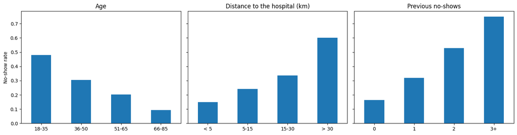

```python
fig, axes = plt.subplots(1, 3, figsize=(15, 4), sharey=True)

groups = [
    (pd.cut(df['age'], [17, 35, 50, 65, 85], labels=['18-35', '36-50', '51-65', '66-85']), 'Age'),
    (pd.cut(df['distance_km'], [0, 5, 15, 30, 60], labels=['< 5', '5-15', '15-30', '> 30']), 'Distance to the hospital (km)'),
    (df['previous_no_shows'].clip(upper=3).map({0: '0', 1: '1', 2: '2', 3: '3+'}), 'Previous no-shows'),
]
for ax, (group, title) in zip(axes, groups):
    df.groupby(group, observed=True)['no_show'].mean().plot.bar(ax=ax, color='tab:blue')
    ax.set_title(title)
    ax.set_xlabel('')
    ax.tick_params(axis='x', rotation=0)
axes[0].set_ylabel('No-show rate')
plt.tight_layout()
plt.show()
```

Younger patients, patients who live far away and patients who have missed appointments before are absent more often. No single variable decides on its own: the model will have to combine them.

### Step 3: Prepare the data

We split the appointments into a **training set** (75%), which the model learns from, and a **test set** (25%), which we keep aside to evaluate it on appointments it has never seen. `stratify=y` keeps the same proportion of no-shows in both sets.

Then we **scale** the features: we subtract the mean and divide by the standard deviation, so that every variable is measured in "standard deviations". Without this, a variable in km and another in days would have very different sizes and gradient descent would converge slowly. The mean and standard deviation are computed **only on the training set** and applied to both sets: the test set must not influence training in any way.

```python
feature_names = ['age', 'days_since_last_visit', 'distance_km', 'hour', 'first_visit', 'previous_no_shows']
X = df[feature_names].to_numpy(dtype=float)
y = df['no_show'].to_numpy()

X_train, X_test, y_train, y_test = train_test_split(
    X, y, test_size=0.25, random_state=42, stratify=y)

# Scaling with the statistics of the TRAINING set only
mean = X_train.mean(axis=0)
std = X_train.std(axis=0)
X_train_s = (X_train - mean) / std
X_test_s = (X_test - mean) / std

print(f"Training set: {len(y_train)} appointments ({y_train.mean():.1%} no-shows)")
print(f"Test set:     {len(y_test)} appointments ({y_test.mean():.1%} no-shows)")
```

```
Training set: 900 appointments (26.2% no-shows)
Test set:     300 appointments (26.3% no-shows)
```

### Step 4: The sigmoid function

The sigmoid $\sigma(z) = \frac{1}{1 + e^{-z}}$ turns the linear score $z$ into a probability: large positive scores give probabilities close to 1, large negative scores give probabilities close to 0, and $z = 0$ gives exactly 0.5, the default threshold.

```
sigmoid(-4) = 0.018
sigmoid(-2) = 0.119
sigmoid( 0) = 0.500
sigmoid( 2) = 0.881
sigmoid( 4) = 0.982
```

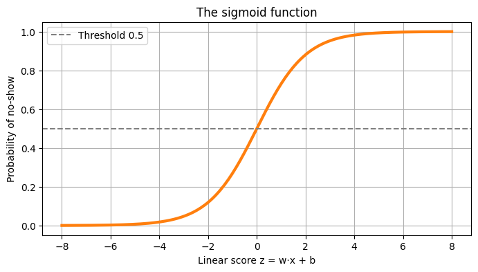

```python
def sigmoid(z):
    """Maps any real number (or array) to a value between 0 and 1."""
    return 1 / (1 + np.exp(-z))

for z in [-4, -2, 0, 2, 4]:
    print(f"sigmoid({z:>2}) = {sigmoid(z):.3f}")

z = np.linspace(-8, 8, 200)
plt.figure(figsize=(8, 4))
plt.plot(z, sigmoid(z), color='tab:orange', linewidth=3)
plt.axhline(0.5, color='gray', linestyle='--', label='Threshold 0.5')
plt.xlabel('Linear score z = w·x + b')
plt.ylabel('Probability of no-show')
plt.title('The sigmoid function')
plt.legend()
plt.grid(True)
plt.show()
```

### Step 5: The cost function: cross-entropy (log loss)

To measure how wrong the model is we cannot use the mean squared error of chapter 2: with a sigmoid it produces a cost surface with many valleys. Logistic regression uses the **cross-entropy**, or *log loss*:

$$J(w, b) = -\frac{1}{m} \sum_{i=1}^{m} \Big[ y_i \log(\hat{p}_i) + (1 - y_i) \log(1 - \hat{p}_i) \Big]$$

For a patient who did not attend ($y = 1$) only the first term counts, $-\log(\hat{p})$: it is almost 0 if the model gave a probability close to 1, and it grows without limit as that probability approaches 0. Confident mistakes are punished hard.

```python
def compute_cost(X, y, w, b):
    """Cross-entropy (log loss) of the model with weights w and bias b."""
    p = sigmoid(X @ w + b)
    p = np.clip(p, 1e-15, 1 - 1e-15)  # avoids log(0)
    return -np.mean(y * np.log(p) + (1 - y) * np.log(1 - p))

# The cost of a single patient who did NOT attend (y = 1):
for p in [0.9, 0.5, 0.1]:
    print(f"The model predicted p = {p}: cost = {-np.log(p):.3f}")
```

```
The model predicted p = 0.9: cost = 0.105
The model predicted p = 0.5: cost = 0.693
The model predicted p = 0.1: cost = 2.303
```

### Step 6: Training with gradient descent

The gradients of the cross-entropy have exactly the same form as in linear regression; the only difference is that the prediction now goes through the sigmoid:

$$\frac{\partial J}{\partial w} = \frac{1}{m} X^\top (\hat{p} - y) \qquad \frac{\partial J}{\partial b} = \frac{1}{m} \sum_{i=1}^{m} (\hat{p}_i - y_i)$$

and the update rule is the one we already know: $w := w - \alpha \frac{\partial J}{\partial w}$ and $b := b - \alpha \frac{\partial J}{\partial b}$, where $\alpha$ is the learning rate. Because the features are scaled, a learning rate of 0.1 converges quickly.

```
Iteration    0: cost = 0.6807
Iteration  500: cost = 0.3523
Iteration 1000: cost = 0.3511
Iteration 1500: cost = 0.3511
Iteration 2000: cost = 0.3511
Iteration 2500: cost = 0.3511

Final cost: 0.3511
Learned weights (w): [-1.269  1.169  1.02   0.365  0.286  1.026]
Learned bias (b): -1.808
```

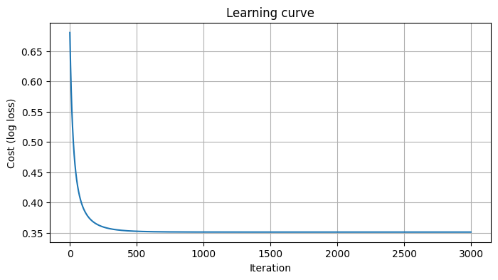

```python
def train_logistic(X, y, learning_rate=0.1, num_iterations=3000):
    """Batch gradient descent on the cross-entropy. Returns w, b and the cost of every iteration."""
    m, n = X.shape
    w = np.zeros(n)
    b = 0.0
    costs = []
    for i in range(num_iterations):
        p = sigmoid(X @ w + b)          # a) predict with the current parameters
        dw = (1 / m) * X.T @ (p - y)    # b) gradients
        db = (1 / m) * np.sum(p - y)
        w = w - learning_rate * dw      # c) one step downhill
        b = b - learning_rate * db
        costs.append(compute_cost(X, y, w, b))
        if i % 500 == 0:
            print(f"Iteration {i:4d}: cost = {costs[-1]:.4f}")
    return w, b, costs

w, b, costs = train_logistic(X_train_s, y_train)
print(f"\nFinal cost: {costs[-1]:.4f}")
print("Learned weights (w):", w)
print(f"Learned bias (b): {b:.3f}")

plt.figure(figsize=(8, 4))
plt.plot(costs)
plt.xlabel('Iteration')
plt.ylabel('Cost (log loss)')
plt.title('Learning curve')
plt.grid(True)
plt.show()
```

The cost falls quickly and then flattens: the model has converged.

### Step 7: Evaluating the model

With a threshold we turn each probability into a prediction, and comparing the predictions with what really happened gives four possible outcomes, the **confusion matrix**:

|  | Predicted: will not attend | Predicted: will attend |
| --- | --- | --- |
| **Did not attend** | True positive (TP) | False negative (FN) |
| **Attended** | False positive (FP) | True negative (TN) |

From it we compute the metrics used in medicine:

- **Accuracy**: $\frac{TP + TN}{\text{total}}$, the share of correct predictions.
- **Sensitivity** (recall): $\frac{TP}{TP + FN}$, the share of no-shows that the model detects.
- **Specificity**: $\frac{TN}{TN + FP}$, the share of attendances that the model recognises.
- **Positive predictive value (PPV)**: $\frac{TP}{TP + FP}$, when the model says "will not attend", how often it is right.
- **Negative predictive value (NPV)**: $\frac{TN}{TN + FN}$, when the model says "will attend", how often it is right.

A useful reference: a "model" that always predicts that every patient will attend already has an accuracy equal to the attendance rate, without detecting a single no-show. Our model has to beat that.

```python
def predict_proba(X, w, b):
    return sigmoid(X @ w + b)

def evaluate(y_true, p, threshold=0.5):
    """Confusion matrix and clinical metrics for a given threshold."""
    y_pred = (p >= threshold).astype(int)
    tp = np.sum((y_pred == 1) & (y_true == 1))
    fn = np.sum((y_pred == 0) & (y_true == 1))
    fp = np.sum((y_pred == 1) & (y_true == 0))
    tn = np.sum((y_pred == 0) & (y_true == 0))
    return {
        'threshold': threshold, 'TP': tp, 'FN': fn, 'FP': fp, 'TN': tn,
        'accuracy': (tp + tn) / len(y_true),
        'sensitivity': tp / (tp + fn),
        'specificity': tn / (tn + fp),
        'PPV': tp / (tp + fp),
        'NPV': tn / (tn + fn),
    }

p_test = predict_proba(X_test_s, w, b)
r = evaluate(y_test, p_test, threshold=0.5)

print("Confusion matrix (test set, threshold 0.5):")
print(f"                  Predicted no-show   Predicted attends")
print(f"  Did not attend  TP = {r['TP']:<14} FN = {r['FN']}")
print(f"  Attended        FP = {r['FP']:<14} TN = {r['TN']}")
print()
for k in ['accuracy', 'sensitivity', 'specificity', 'PPV', 'NPV']:
    print(f"{k:>12}: {r[k]:.3f}")
print(f"\nBaseline (always predict 'attends'): accuracy = {1 - y_test.mean():.3f}")
```

```
Confusion matrix (test set, threshold 0.5):
                  Predicted no-show   Predicted attends
  Did not attend  TP = 49             FN = 30
  Attended        FP = 22             TN = 199

    accuracy: 0.827
 sensitivity: 0.620
 specificity: 0.900
         PPV: 0.690
         NPV: 0.869

Baseline (always predict 'attends'): accuracy = 0.737
```

The model beats the baseline, and it is very reliable when it says that a patient *will* attend (high NPV). But with the default threshold it only detects a part of the no-shows (the sensitivity): many absences go unnoticed.

### Step 8: Choosing the threshold

The 0.5 threshold is only a convention. **Lowering it** makes the model flag more patients as likely no-shows: sensitivity goes up (fewer absences slip through), but so do the false alarms, so specificity and PPV go down. Which balance is better is not a mathematical question but a clinical and organisational one: here a false alarm costs a reminder phone call, while a missed no-show costs an empty slot on a waiting list.

```python
table = pd.DataFrame([evaluate(y_test, p_test, t) for t in [0.5, 0.4, 0.3, 0.2]])
table.round(3)
```

|  | threshold | TP | FN | FP | TN | accuracy | sensitivity | specificity | PPV | NPV |
| --- | --- | --- | --- | --- | --- | --- | --- | --- | --- | --- |
| 0 | 0.5 | 49 | 30 | 22 | 199 | 0.827 | 0.620 | 0.900 | 0.690 | 0.869 |
| 1 | 0.4 | 54 | 25 | 32 | 189 | 0.810 | 0.684 | 0.855 | 0.628 | 0.883 |
| 2 | 0.3 | 61 | 18 | 46 | 175 | 0.787 | 0.772 | 0.792 | 0.570 | 0.907 |
| 3 | 0.2 | 68 | 11 | 64 | 157 | 0.750 | 0.861 | 0.710 | 0.515 | 0.935 |

With a threshold of 0.3 the model detects many more no-shows, at the cost of more reminder calls to patients who would have come anyway.

### Step 9: Interpreting the coefficients

Because the features are scaled, the weights are comparable with each other: each one says how much the log-odds of a no-show change when that variable increases by one standard deviation, with the others fixed. Its exponential, $e^{w}$, is the **odds ratio**: a value of 2 doubles the odds of a no-show, a value of 0.5 halves them.

```
                       weight  odds ratio
age                    -1.269       0.281
days_since_last_visit   1.169       3.217
previous_no_shows       1.026       2.791
distance_km             1.020       2.774
hour                    0.365       1.440
first_visit             0.286       1.332
```

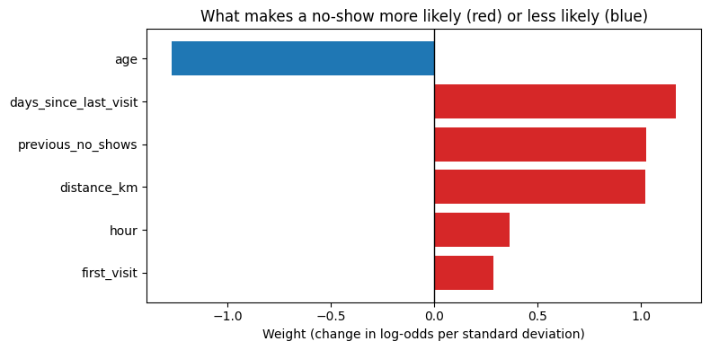

```python
coefficients = pd.DataFrame({'weight': w, 'odds ratio': np.exp(w)}, index=feature_names)
coefficients = coefficients.reindex(coefficients['weight'].abs().sort_values(ascending=False).index)
print(coefficients.round(3))

plt.figure(figsize=(8, 4))
plt.barh(coefficients.index[::-1], coefficients['weight'][::-1],
         color=['tab:red' if v > 0 else 'tab:blue' for v in coefficients['weight'][::-1]])
plt.axvline(0, color='black', linewidth=1)
plt.xlabel('Weight (change in log-odds per standard deviation)')
plt.title('What makes a no-show more likely (red) or less likely (blue)')
plt.tight_layout()
plt.show()
```

The model has found the pattern the team suspected, and the same three variables the book highlights come out on top. **Age** is the strongest signal: each standard deviation of age (about 20 years) multiplies the odds of a no-show by about 0.28, so older patients miss far fewer appointments. The **days since the last visit** (×3.2), the **previous no-shows** (×2.8) and the **distance** to the hospital (×2.8) raise the risk. The time of the appointment (×1.4) and the type of visit (×1.3) matter less. These are associations learned from the data, not causes: they tell the team whom to call, not why a patient misses an appointment.

### Step 10: Predicting for new patients

```python
# age, days since last visit, distance (km), hour, first visit, previous no-shows
new_patients = np.array([
    [35, 100, 18.0, 18, 1, 0],   # young, long gap, lives far away, late slot, first visit
    [33,  80, 14.0, 17, 1, 0],   # similar, but a little closer to the usual profile
    [62,  30,  6.0,  9, 0, 0],   # older, recent follow-up, lives nearby, morning slot
])
p_new = predict_proba((new_patients - mean) / std, w, b)

for patient, p in zip(new_patients, p_new):
    flag_05 = "flagged" if p >= 0.5 else "not flagged"
    flag_03 = "flagged" if p >= 0.3 else "not flagged"
    print(f"Patient aged {patient[0]:.0f}: P(no-show) = {p:5.1%} | threshold 0.5: {flag_05:<11} | threshold 0.3: {flag_03}")
```

```
Patient aged 35: P(no-show) = 57.5% | threshold 0.5: flagged     | threshold 0.3: flagged
Patient aged 33: P(no-show) = 36.0% | threshold 0.5: not flagged | threshold 0.3: flagged
Patient aged 62: P(no-show) =  0.3% | threshold 0.5: not flagged | threshold 0.3: not flagged
```

The second patient shows why the threshold matters: with 0.5 the model would not flag them, with 0.3 the team would call to confirm the appointment.

### Conclusion

We have built a logistic regression from scratch: the sigmoid turns a linear score into a probability, the cross-entropy measures the error, and gradient descent adjusts the weights exactly as it did in linear regression.

We have also seen that a classifier is not evaluated with a single number. Accuracy hides the fact that, with the default threshold, many no-shows go undetected; sensitivity, specificity, PPV and NPV tell the whole story, and the threshold lets the team choose the balance that suits the hospital.

In the next notebook, *Logistic regression with scikit-learn*, we will train the same model with a library and add two tools from this chapter: **regularization**, to avoid overfitting, and **k-fold cross-validation**, to choose its strength.